# MXB107 R Code Snippets

Dan Tran

2022-10-25

**This document is intended to help with R Programming only. For mathematical explanation, please refer to the weekly [[Readings]](https://blackboard.qut.edu.au/bbcswebdav/pid-1481644-dt-announcement-rid-58665563_1/courses/MXB107_22se2/_site/index.html).**

Workshop notes (Tuesday 9-11am) can be found **[here]**.

If you prefer the PDF, find them on my [**[GitHub]**](https://github.com/autumnssuns/MXB107_FAQ/releases/tag/auto-release) (then download `index.pdf` and `notes.pdf` from Assets).

Set up the MXB107 package. The commented lines can be used to install dependencies (only when required by R).

```r
install.packages(c( "tidyverse", "knitr", "rmarkdown", "pander",
"ggforce", "kableExtra", "gridExtra"))
```

[output not shown]

```r
# Use knitr to install tinytex
# library(knitr)

# install.packages("tinytex")
# tinytex::install_tinytex(force = TRUE)
install.packages("MXB107_1.0.0.2022.zip", repos = NULL, type="source")
library(MXB107)
```

# Assignment 2

## Question 2

Since $n=30$, you can use either the Gaussian or Student’ t distribution.

Find a critical Z value, from a Gaussian distribution, given a type I error rate $\alpha = 0.05$:

```r
alpha <- 0.05
Z_alpha_half <- qnorm(1 - alpha/2)
Z_alpha_half
```

```
## [1] 1.959964
```

Find a critical T value, from a Student’ t distribution, given a type I error rate $\alpha = 0.05$ and degree of freedom $\nu = 16$:

```r
alpha <- 0.05
nu <- 16
T_critical <- qt(1 - alpha/2, nu)
T_critical
```

```
## [1] 2.119905
```

## Question 5

Given code in assignment template (swimmer data).

```r
df<-data.frame(s1 = c(59.62,59.74,59.48,59.43,59.65,59.72,59.50,59.63,60.01,59.68),s2 = c(59.81,59.41,59.32,59.63,59.76,59.50,59.64,59.83,59.86,59.51))

kable(df,col.names=c("Swimmer 1","Swimmer 2"),booktabs = TRUE, linesep = "") %>%
  kable_styling(position = "center",full_width = FALSE)
```

| Swimmer 1 | Swimmer 2 |
| --- | --- |
| 59.62 | 59.81 |
| 59.74 | 59.41 |
| 59.48 | 59.32 |
| 59.43 | 59.63 |
| 59.65 | 59.76 |
| 59.72 | 59.50 |
| 59.50 | 59.64 |
| 59.63 | 59.83 |
| 60.01 | 59.86 |
| 59.68 | 59.51 |

Find the mean, standard deviation and variance of the two swimmers.

```r
df %>% summarise_all(.funs = list(mean = ~mean(.), sd = ~sd(.), var = ~var(.)))
```

| s1_mean | s2_mean | s1_sd | s2_sd | s1_var | s2_var |
| --- | --- | --- | --- | --- | --- |
| 59.646 | 59.627 | 0.1648029 | 0.1879746 | 0.02716 | 0.03533444 |

**Only use the following two snippets if needed for paired difference**:

```r
diff <- data.frame(Difference = df$s2 - df$s1)
kable(diff,booktabs = FALSE,linesep="") %>%
  kable_styling(position = "center", full_width = FALSE)
```

| Difference |
| --- |
| 0.19 |
| -0.33 |
| -0.16 |
| 0.20 |
| 0.11 |
| -0.22 |
| 0.14 |
| 0.20 |
| -0.15 |
| -0.17 |

Find the mean and standard deviation of the difference:

```r
diff %>% summarise_at("Difference", .funs = list(mean = ~mean(.), sd = ~sd(.)))
```

| mean | sd |
| --- | --- |
| -0.019 | 0.2050718 |

## Question 6

Given code in assignment template (experiment data).

```r
df<-data.frame(Person = c(1,2,3,4,5,6,7),Before = c(4,5,5,4,3,6,2),After = c(7,8,3,5,4,5,5))
kable(df,booktabs = FALSE,linesep="") %>%
  kable_styling(position = "center", full_width = FALSE)
```

| Person | Before | After |
| --- | --- | --- |
| 1 | 4 | 7 |
| 2 | 5 | 8 |
| 3 | 5 | 3 |
| 4 | 4 | 5 |
| 5 | 3 | 4 |
| 6 | 6 | 5 |
| 7 | 2 | 5 |

Find mean, standard deviation and variance before and after the experiment:

```r
df %>% summarise_at(c("Before", "After"), .funs = list(mean = ~mean(.), sd = ~sd(.), var = ~var(.)))
```

| Before_mean | After_mean | Before_sd | After_sd | Before_var | After_var |
| --- | --- | --- | --- | --- | --- |
| 4.142857 | 5.285714 | 1.345185 | 1.704336 | 1.809524 | 2.904762 |

**Only use the following two snippets if needed for paired difference**:

Find the difference between after and before the experiment:

```r
diff <- data.frame(Person = df$Person, Difference = df$After - df$Before)
kable(diff,booktabs = FALSE,linesep="") %>%
  kable_styling(position = "center", full_width = FALSE)
```

| Person | Difference |
| --- | --- |
| 1 | 3 |
| 2 | 3 |
| 3 | -2 |
| 4 | 1 |
| 5 | 1 |
| 6 | -1 |
| 7 | 3 |

Find the mean and standard deviation of the difference:

```r
diff %>% summarise_at("Difference", .funs = list(mean = ~mean(.), sd = ~sd(.)))
```

| mean | sd |
| --- | --- |
| 1.142857 | 2.035401 |

## Question 8

Plotting the distribution of residuals as a histogram (not required, but may help with your understanding)

```r
model_2 <- lm(height~age+Seed, data = Loblolly)

model_2%>%aov()%>%pander()
```

Analysis of Variance Model

|  | Df | Sum Sq | Mean Sq | F value | Pr(>F) |
| --- | --- | --- | --- | --- | --- |
| **age** | 1 | 34762 | 34762 | 4374 | 3.8e-64 |
| **Seed** | 13 | 163.7 | 12.59 | 1.584 | 0.1112 |
| **Residuals** | 69 | 548.4 | 7.947 | NA | NA |

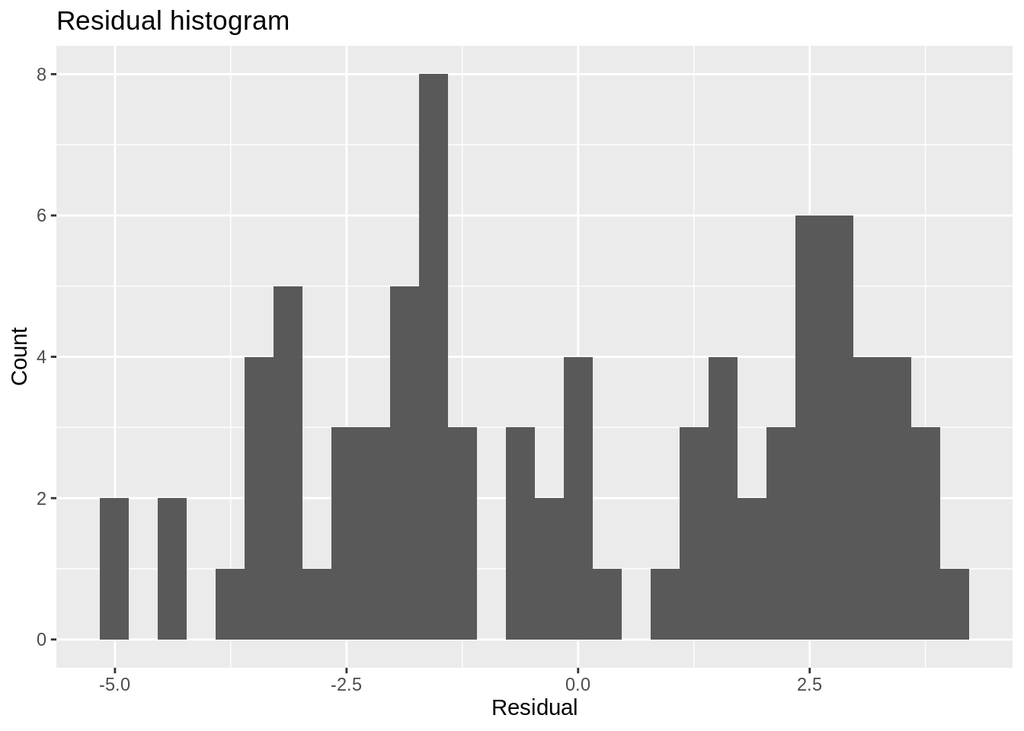

```r
df <- tibble(Loblolly,resid = model_2$residuals, fitted.values = model_2$fitted.values)

df %>%
  ggplot(aes(x = resid)) +
  geom_histogram(bins = 30) +
  ggtitle("Residual histogram") +
  xlab("Residual") +
  ylab("Count")
```

# Assignment 1

Load the `episodes` data set.

```r
data(episodes)
```

## Part 1: Summarising Data

### Question 1

Shows the IMDB rankings for each series of *Star Trek*.

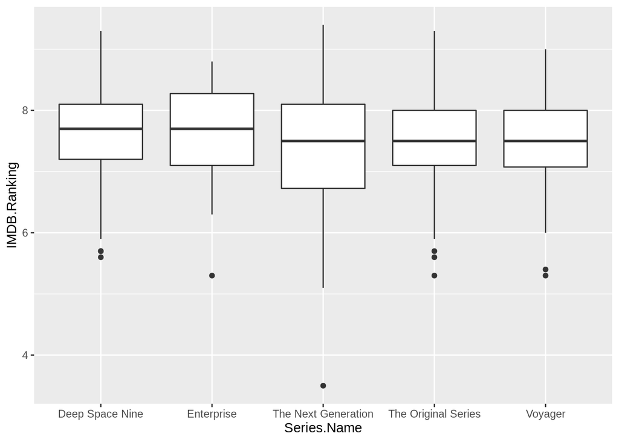

```r
ggplot(episodes, aes(x = Series.Name, y = IMDB.Ranking))+
  geom_boxplot()
```

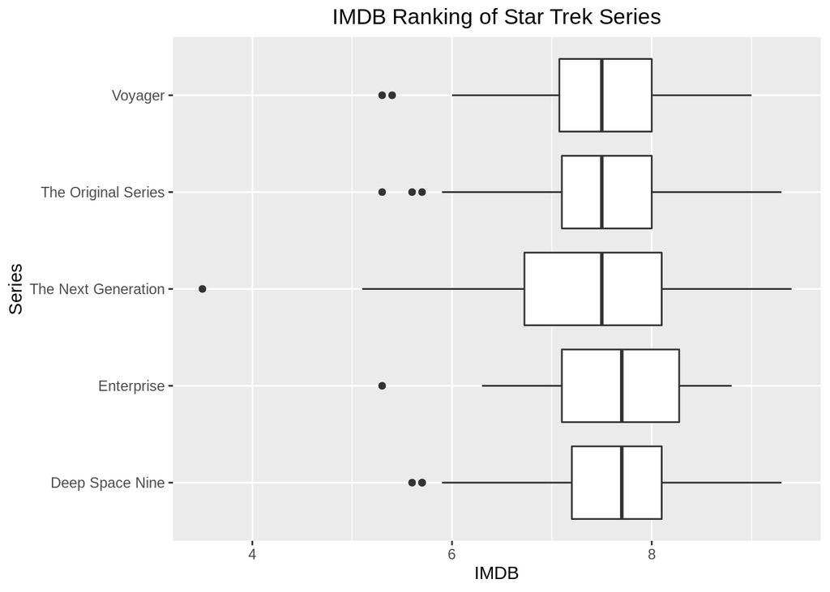

```r
ggplot(episodes, aes(y = Series.Name, x = IMDB.Ranking))+ # Changed x and y order for horizontal
  geom_boxplot()+                                         # Add boxplot
  xlab("IMDB")+                                           # Add x-label
  ylab("Series")+                                         # Add y-label
  ggtitle("IMDB Ranking of Star Trek Series")+            # Add title
  theme(plot.title=element_text(hjust=0.5))               # Adjust title to middle
```

Create pair of histograms for IMDB rankings of **Star Trek: The Next Generation** based on Bechdel-Wallace Test status. The `aes(y=..density..)` is used to display the density rather than count.

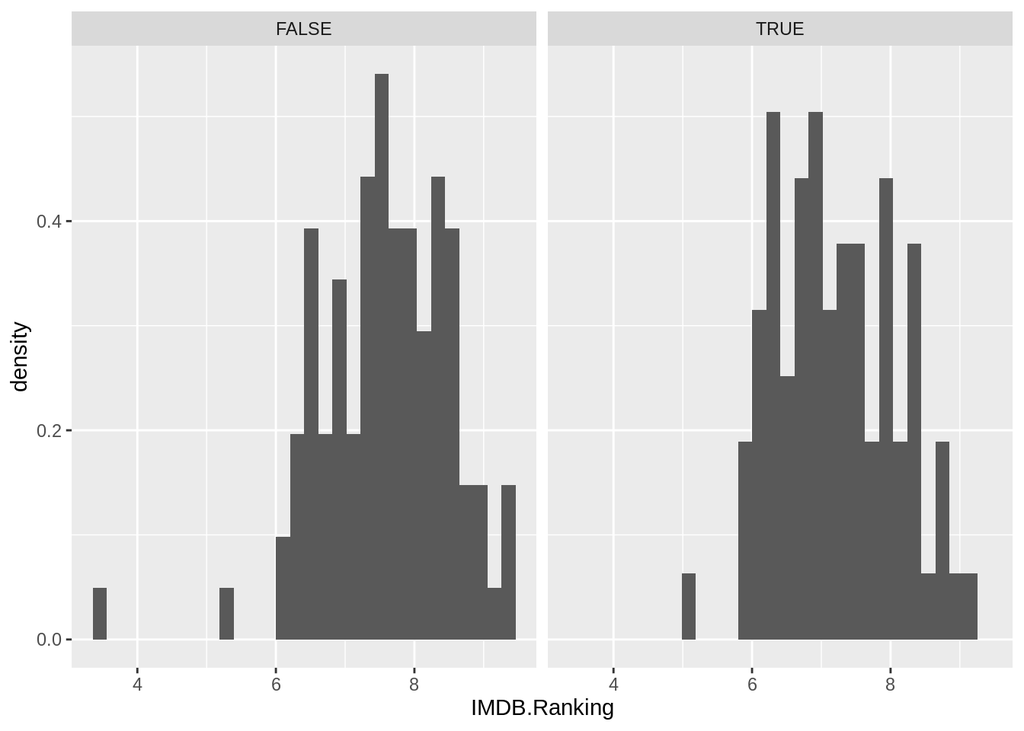

```r
filter(episodes,Series.Name=="The Next Generation")%>%
  ggplot(aes(x=IMDB.Ranking))+
  geom_histogram(aes(y=..density..), bins = 30)+
  facet_wrap(~Bechdel.Wallace.Test)
```

### Question 2

Find the total number of rows in the `episodes` table. The `<-` operator assigns the value of the right hand side to the variable on the left-hand side (can be named anything, not just `n`).

```r
n <- nrow(episodes)
n # To display the value of a variable, call it like this, or print(n)
```

```
## [1] 704
```

Find the mean IMDB ranking. **`episodes$IMDB.Ranking` selects the `IMDB.Ranking` column from the `episodes` dataframe.**

```r
mean <- mean(episodes$IMDB.Ranking)
mean
```

```
## [1] 7.55071
```

Find the sum of squared distances from the mean IMDB Ranking, with `mean` already found above. Equivalent to
$$\sum_{i=1}^n{(x_i-\bar{x})^2}$$

```r
x <- episodes$IMDB.Ranking
sum_of_squared_distances <- sum((x - mean)^2)
sum_of_squared_distances
```

```
## [1] 423.3796
```

Display the histogram of the episode’s IMDB rankings.

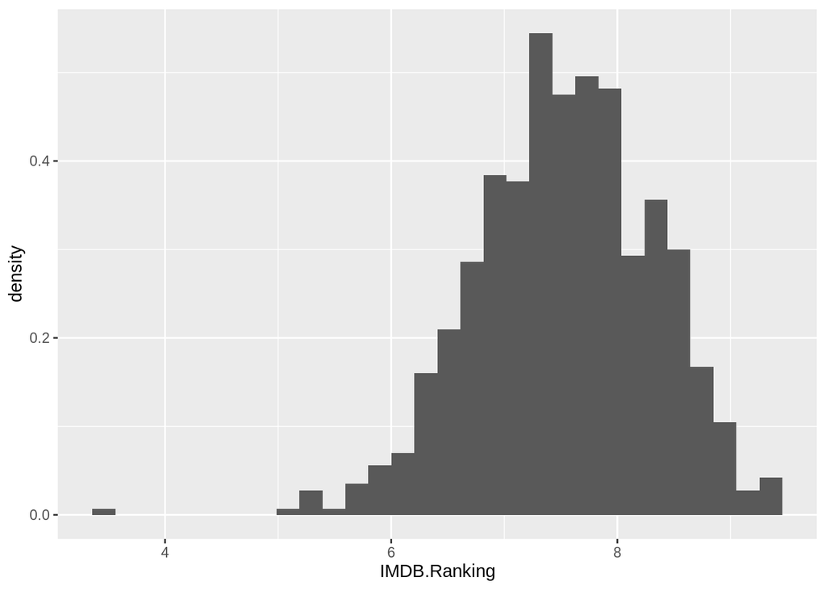

```r
episodes %>%
  ggplot(aes(x = IMDB.Ranking))+
  geom_histogram(aes(y = ..density..), bins = 30)
```

## Part 2: Computing Basic Probabilities for Events

### Question 1,2 & 3

*Basically counting things*

Find the number of episodes passing the Bechdel Wallace Test.

```r
pass_count <- sum(episodes$Bechdel.Wallace.Test == TRUE)
pass_count
```

```
## [1] 366
```

The condition `episodes$Bechdel.Wallace.Test == TRUE` can be changed to any other condition, such as: Number of episodes from *Star Trek: The Original Series*.

```r
original_count <- sum(episodes$Series.Name == "The Original Series")
original_count
```

```
## [1] 80
```

Or the number of episodes from *Star Trek: The Original Series* and pass the Bechdel-Wallace Test. You can apply multiple conditions using the `&` operator between the two comparisons.

```r
original_pass_count <- sum(episodes$Series.Name == "The Original Series" &
                             episodes$Bechdel.Wallace.Test == TRUE)
original_pass_count
```

```
## [1] 5
```

### Question 4

*More advanced counting by accounting for categorical data*

The number of episodes of each season for each series, that already passed the Bechdel Wallace Test. *Don’t worry if the last two lines don’t make sense.*

```r
episodes%>%
  filter(Bechdel.Wallace.Test == TRUE)%>% # Remove this filter for all episodes
  group_by(Series.Name, Season)%>%
  tally()%>%
  pivot_wider(names_from = Series.Name, values_from = n)%>%
  bind_rows(summarise_all(., ~sum(., na.rm=TRUE)))%>% # Total column
  mutate(Total = rowSums(.[setdiff(names(.),"Season")], na.rm = TRUE)) # Total row
```

| Season | Deep Space Nine | Enterprise | The Next Generation | The Original Series | Voyager | Total |
| --- | --- | --- | --- | --- | --- | --- |
| 1 | 13 | 11 | 10 | NA | 14 | 48 |
| 2 | 17 | 9 | 9 | 2 | 24 | 61 |
| 3 | 19 | 9 | 9 | 3 | 17 | 57 |
| 4 | 12 | 9 | 12 | NA | 24 | 57 |
| 5 | 13 | NA | 16 | NA | 23 | 52 |
| 6 | 12 | NA | 10 | NA | 23 | 45 |
| 7 | 14 | NA | 12 | NA | 20 | 46 |
| 28 | 100 | 38 | 78 | 5 | 145 | 366 |

## Part 3: Modelling with Probability Distributions

### Question 1 & 2

*In R, given any distribution (Binomial, Geometric, Poisson, Normal, etc.), the Probability Density Function* $Pr(X = x)$ can be found using `d<distribution name>`, and the cumulative probability can be found using `p<distribution name>`. I show the Geometric distribution as an example.

Given $X \sim Geom(0.5)$, find $Pr(X=2)$.

```r
dgeom(2, prob = 0.5)
```

```
## [1] 0.125
```

Given $X \sim Geom(0.5)$, find $Pr(X \leq 2)$.

```r
pgeom(2, prob = 0.5)
```

```
## [1] 0.875
```

For other distributions, please refer to the documentation [[here]](https://cran.r-project.org/web/views/Distributions.html), or a slightly more visually engaging example [[here]](https://rstudio-pubs-static.s3.amazonaws.com/100906_8e3a32dd11c14b839468db756cee7400.html).

### Question 3

Plot the probability distributions for the number of successes out of 10 trials, with a success probability of 0.5; using the Binomial $X_B \sim Binom(10,0.5)$ and Poisson $X_P \sim Pois(10\times0.5)$.

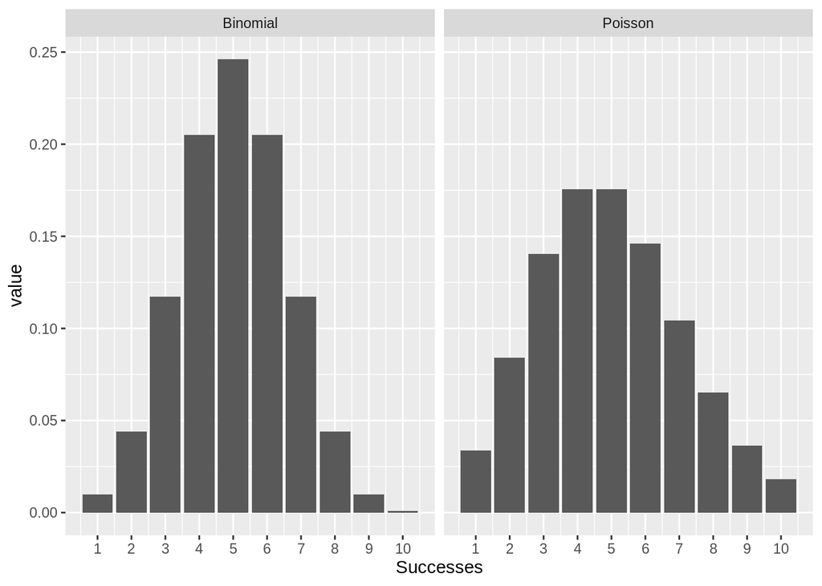

```r
n <- 10
p <- 0.5

number_of_successes <- 1:n

# Generate the dataframe with 3 columns: Successes, Binomial, Poisson
data <- data.frame(Successes = number_of_successes,
                   Binomial = dbinom(number_of_successes,n,p),
                   Poisson = dpois(number_of_successes,n*p))
# Plot side-by-side plots
data %>%
  pivot_longer(cols = -c(Successes), names_to = "Distribution") %>%
  ggplot(aes(x = Successes, y = value))+
  scale_x_continuous(breaks=data$Successes)+
  geom_bar(stat="identity")+
  facet_wrap(~Distribution)
```

## Extra

### Embed an image

Use `![](path\to\image)`. Replace the `path\to\image` with the actual path to your image. For example. I have a `QUT_Logo.jpg` in the same folder as my `R Markdown` file, which can be added using `![](QUT_Logo.jpg)`.

[figure not shown]

### R Markdown Cheatsheet

Access RStudio’s R Markdown Cheatsheet [[Here]](https://www.rstudio.com/wp-content/uploads/2015/02/rmarkdown-cheatsheet.pdf).